# hw3

HyeongHwan Kim

2023-10-26

```r
library(tidyverse)
library(nycflights13)
```

# Textbook 5.6

## Problem 1

Restyle the following pipelines following the guidelines above.

```r
flights |>
  filter(dest == "IAH") |>
  group_by(year, month, day) |>
  summarize(n = n(),
 delay = mean(arr_delay, na.rm=TRUE)) |>
  filter(n > 10)
```

```
## # A tibble: 365 × 5
## # Groups:   year, month [12]
##     year month   day     n delay
##    <int> <int> <int> <int> <dbl>
##  1  2013     1     1    20 17.8
##  2  2013     1     2    20  7
##  3  2013     1     3    19 18.3
##  4  2013     1     4    20 -3.2
##  5  2013     1     5    13 20.2
##  6  2013     1     6    18  9.28
##  7  2013     1     7    19 -7.74
##  8  2013     1     8    19  7.79
##  9  2013     1     9    19 18.1
## 10  2013     1    10    19  6.68
## # ℹ 355 more rows
```

```r
flights |>
  filter(carrier == "UA", dest %in% c("IAH", "HOU"), sched_dep_time >
 0900, sched_arr_time < 2000) |>
  group_by(flight) |>
  summarize(delay = mean(
arr_delay, na.rm=TRUE), cancelled = sum(is.na(arr_delay)), n = n()) |>
  filter(n > 10)
```

```
## # A tibble: 74 × 4
##    flight delay cancelled     n
##     <int> <dbl>     <int> <int>
##  1     53 12.5          2    18
##  2    112 14.1          0    14
##  3    205 -1.71         0    14
##  4    235 -5.36         0    14
##  5    255 -9.47         0    15
##  6    268 38.6          1    15
##  7    292  6.57         0    21
##  8    318 10.7          1    20
##  9    337 20.1          2    21
## 10    370 17.5          0    11
## # ℹ 64 more rows
```

# Textbook 17.3.1

## Problem 1

Explore the distribution of rincome (reported income). What makes the default bar chart hard to understand? How could you improve the plot?

```r
cat_data <- forcats::gss_cat
```

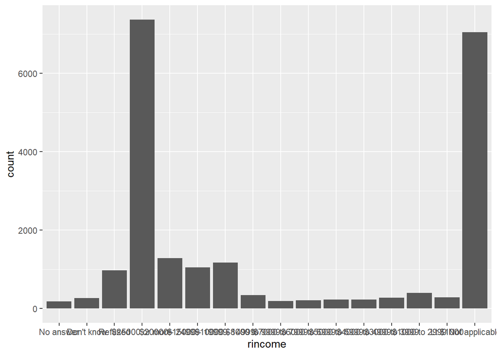

```r
ggplot(cat_data, mapping = aes(x = rincome)) +
  geom_bar()
```

x-labels overlap each other.

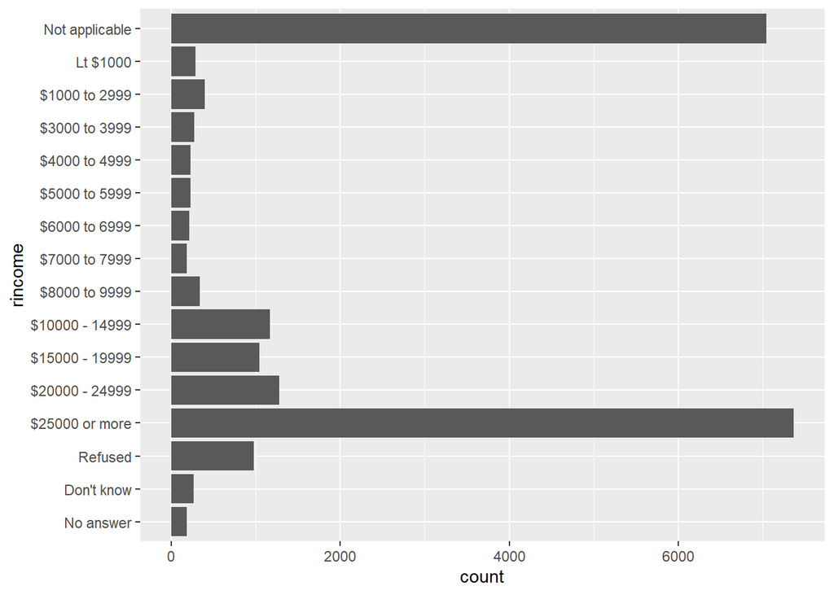

```r
ggplot(cat_data, mapping = aes(x = rincome)) +
  geom_bar() +
  coord_flip()
```

## Problem 2

What is the most common relig in this survey? What’s the most common partyid?

```r
cat_data %>%
  group_by(relig) %>%
  summarise(n = n())
```

```
## # A tibble: 15 × 2
##    relig                       n
##    <fct>                   <int>
##  1 No answer                  93
##  2 Don't know                 15
##  3 Inter-nondenominational   109
##  4 Native american            23
##  5 Christian                 689
##  6 Orthodox-christian         95
##  7 Moslem/islam              104
##  8 Other eastern              32
##  9 Hinduism                   71
## 10 Buddhism                  147
## 11 Other                     224
## 12 None                     3523
## 13 Jewish                    388
## 14 Catholic                 5124
## 15 Protestant              10846
```

Protestant is the most common religion.

```r
cat_data %>%
  group_by(partyid) %>%
  summarise(n = n())
```

```
## # A tibble: 10 × 2
##    partyid                n
##    <fct>              <int>
##  1 No answer            154
##  2 Don't know             1
##  3 Other party          393
##  4 Strong republican   2314
##  5 Not str republican  3032
##  6 Ind,near rep        1791
##  7 Independent         4119
##  8 Ind,near dem        2499
##  9 Not str democrat    3690
## 10 Strong democrat     3490
```

Independent is the most common partyid

# Textbook 17.4.1

## Problem 1

There are some suspiciously high numbers in tvhours. Is the mean a good summary?

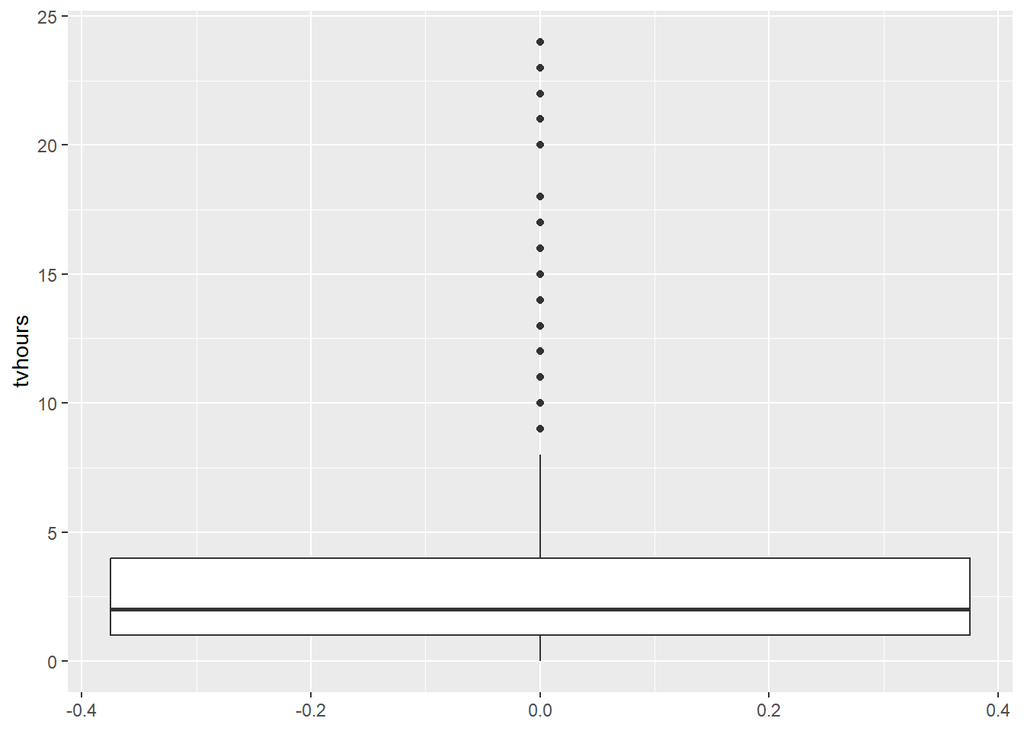

```r
ggplot(data = cat_data, mapping = aes(y = tvhours)) +
  geom_boxplot()
```

Looking at the box plot above, it’s evident that there are numerous outliers. Therefore, using the mean, which is not a robust statistic, may not be appropriate.

## Problem 2

```r
cat_data
```

```
## # A tibble: 21,483 × 9
##     year marital         age race  rincome        partyid    relig denom tvhours
##    <int> <fct>         <int> <fct> <fct>          <fct>      <fct> <fct>   <int>
##  1  2000 Never married    26 White $8000 to 9999  Ind,near … Prot… Sout…      12
##  2  2000 Divorced         48 White $8000 to 9999  Not str r… Prot… Bapt…      NA
##  3  2000 Widowed          67 White Not applicable Independe… Prot… No d…       2
##  4  2000 Never married    39 White Not applicable Ind,near … Orth… Not …       4
##  5  2000 Divorced         25 White Not applicable Not str d… None  Not …       1
##  6  2000 Married          25 White $20000 - 24999 Strong de… Prot… Sout…      NA
##  7  2000 Never married    36 White $25000 or more Not str r… Chri… Not …       3
##  8  2000 Divorced         44 White $7000 to 7999  Ind,near … Prot… Luth…      NA
##  9  2000 Married          44 White $25000 or more Not str d… Prot… Other       0
## 10  2000 Married          47 White $25000 or more Strong re… Prot… Sout…       3
## # ℹ 21,473 more rows
```

marital, race, rincome, partyid, relig, denom columns are factor

```r
levels(cat_data$marital)
```

```
## [1] "No answer"     "Never married" "Separated"     "Divorced"
## [5] "Widowed"       "Married"
```

```r
levels(cat_data$race)
```

```
## [1] "Other"          "Black"          "White"          "Not applicable"
```

```r
levels(cat_data$rincome)
```

```
##  [1] "No answer"      "Don't know"     "Refused"        "$25000 or more"
##  [5] "$20000 - 24999" "$15000 - 19999" "$10000 - 14999" "$8000 to 9999"
##  [9] "$7000 to 7999"  "$6000 to 6999"  "$5000 to 5999"  "$4000 to 4999"
## [13] "$3000 to 3999"  "$1000 to 2999"  "Lt $1000"       "Not applicable"
```

```r
levels(cat_data$partyid)
```

```
##  [1] "No answer"          "Don't know"         "Other party"
##  [4] "Strong republican"  "Not str republican" "Ind,near rep"
##  [7] "Independent"        "Ind,near dem"       "Not str democrat"
## [10] "Strong democrat"
```

```r
levels(cat_data$relig)
```

```
##  [1] "No answer"               "Don't know"
##  [3] "Inter-nondenominational" "Native american"
##  [5] "Christian"               "Orthodox-christian"
##  [7] "Moslem/islam"            "Other eastern"
##  [9] "Hinduism"                "Buddhism"
## [11] "Other"                   "None"
## [13] "Jewish"                  "Catholic"
## [15] "Protestant"              "Not applicable"
```

```r
levels(cat_data$denom)
```

```
##  [1] "No answer"            "Don't know"           "No denomination"
##  [4] "Other"                "Episcopal"            "Presbyterian-dk wh"
##  [7] "Presbyterian, merged" "Other presbyterian"   "United pres ch in us"
## [10] "Presbyterian c in us" "Lutheran-dk which"    "Evangelical luth"
## [13] "Other lutheran"       "Wi evan luth synod"   "Lutheran-mo synod"
## [16] "Luth ch in america"   "Am lutheran"          "Methodist-dk which"
## [19] "Other methodist"      "United methodist"     "Afr meth ep zion"
## [22] "Afr meth episcopal"   "Baptist-dk which"     "Other baptists"
## [25] "Southern baptist"     "Nat bapt conv usa"    "Nat bapt conv of am"
## [28] "Am bapt ch in usa"    "Am baptist asso"      "Not applicable"
```

Except for ‘rincome’ and ‘partyid’, others have arbitrary order.

# Textbook 17.5.1

## Problem 1

How have the proportions of people identifying as Democrat, Republican, and Independent changed over time?

```r
cat_data_n <- cat_data %>%
  mutate(
    partyid = fct_collapse(partyid,
      "other" = c("No answer", "Don't know", "Other party"),
      "rep" = c("Strong republican", "Not str republican"),
      "ind" = c("Ind,near rep", "Independent", "Ind,near dem"),
      "dem" = c("Not str democrat", "Strong democrat"))
  ) %>%
  group_by(year, partyid) %>%
  summarise(n = n())
cat_data_tot <- cat_data_n %>%
  group_by(year) %>%
  summarise(total = sum(n))
```

```r
cat_data_p <- cat_data_n %>%
  left_join(cat_data_tot) %>%
  mutate(p = n / total) %>%
  select(year, partyid, p) %>%
  filter(partyid != 'other')
```

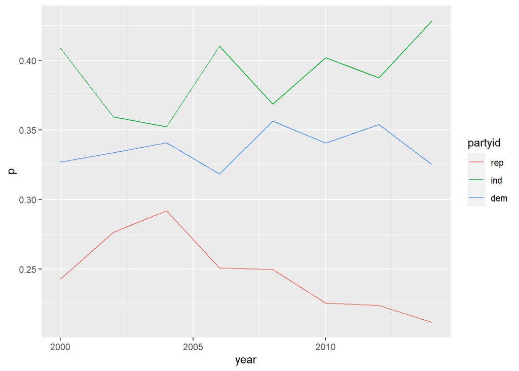

```r
ggplot(cat_data_p, mapping = aes(x = year, y = p, color = partyid)) +
  geom_line()
```

The trend for rep has been consistently decreasing since 2004. ind and dem exhibit a conflicting relationship, with their patterns showing opposite directions of increase and decrease. There doesn’t seem to be a specific trend for them over time.

# Textbook 18.2.5

## Problem 3

For each of the following date-times, show how you’d parse it using a readr column specification and a lubridate function.

```r
library(lubridate)
```

```r
library(readr)
```

```r
d1 <- "January 1, 2010"
d2 <- "2015-Mar-07"
d3 <- "06-Jun-2017"
d4 <- c("August 19 (2015)", "July 1 (2015)")
d5 <- "12/30/14" # Dec 30, 2014
t1 <- "1705"
t2 <- "11:15:10.12 PM"
```

```r
parse_date(d1, "%B %d, %Y")
```

```
## [1] "2010-01-01"
```

```r
mdy(d1)
```

```
## [1] "2010-01-20"
```

mdy function do not recognize d1.

```r
parse_date(d2, "%Y-%b-%d")
```

```
## [1] "2015-03-07"
```

```r
ymd(d2)
```

```
## [1] "2015-03-07"
```

```r
parse_date(d3, "%d-%b-%Y")
```

```
## [1] "2017-06-06"
```

```r
dmy(d3)
```

```
## [1] "2017-06-06"
```

```r
parse_date(d4, "%B %d (%Y)")
```

```
## [1] "2015-08-19" "2015-07-01"
```

```r
mdy(d4)
```

```
## [1] "2015-01-09" "2015-01-20"
```

```r
parse_date(d5, "%m/%d/%y")
```

```
## [1] "2014-12-30"
```

```r
mdy(d5)
```

```
## [1] "2014-12-30"
```

```r
parse_time(t1, "%H%M")
```

```
## 17:05:00
```

```r
hm(paste0(substr(t1, 1, 2), ":", substr(t1, 3, 4)))
```

```
## [1] "17H 5M 0S"
```

hm also do not recognize t1 without adding ‘:’.

```r
parse_time(t2, "%H:%M:%OS %p")
```

```
## 23:15:10.12
```

```r
hms(t2)
```

```
## [1] "11H 15M 10.12S"
```

# Textbook 18.3.4

## Problem 1

How does the distribution of flight times within a day change over the course of the year?

```r
dep_flights <- flights %>%
  mutate(parsed_sched_dep_time = parse_time(
    ifelse(str_length(as.character(sched_dep_time)) == 3,
           paste0("0", as.character(sched_dep_time)),
           as.character(sched_dep_time)), "%H%M")) %>%
  select(month, parsed_sched_dep_time)
```

```r
dep_flights %>%
  mutate(month = as.character(month))
```

```
## # A tibble: 336,776 × 2
##    month parsed_sched_dep_time
##    <chr> <time>
##  1 1     05:15
##  2 1     05:29
##  3 1     05:40
##  4 1     05:45
##  5 1     06:00
##  6 1     05:58
##  7 1     06:00
##  8 1     06:00
##  9 1     06:00
## 10 1     06:00
## # ℹ 336,766 more rows
```

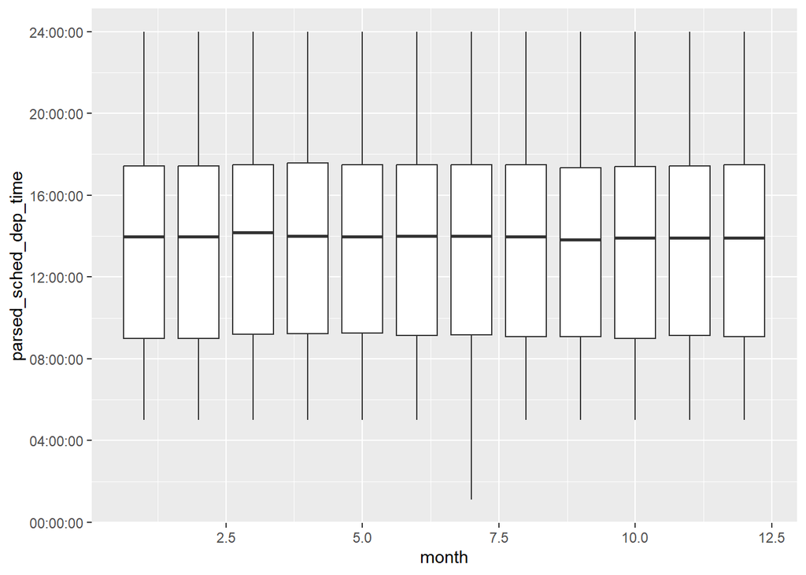

```r
ggplot(dep_flights, mapping = aes(x = month, group = month, y = parsed_sched_dep_time)) +
  geom_boxplot()
```

When drawing a boxplot of departure times by month, it appears that, excluding outliers in July, the distributions are nearly identical.

## Problem 4

How does the average delay time change over the course of a day? Should you use dep_time or sched_dep_time? Why?

```r
d_flights <- flights %>%
  select(hour, dep_delay) %>%
  group_by(hour) %>%
  summarise(avg = mean(dep_delay, na.rm = TRUE))
```

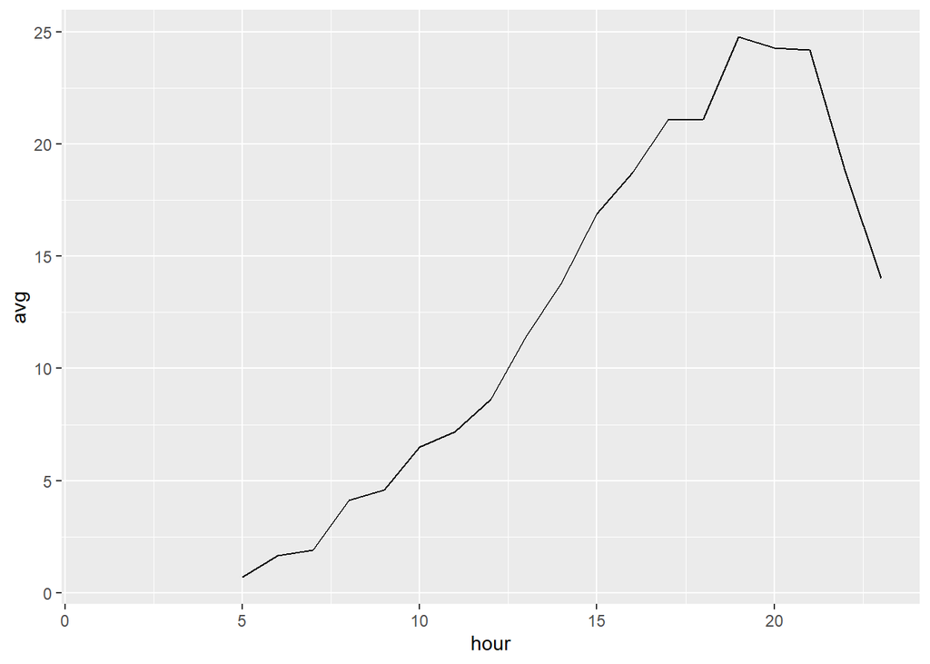

```r
ggplot(d_flights, mapping = aes(x = hour, y = avg)) +
  geom_line()
```

```r
new_d_flights <- flights %>%
  mutate(parsed_sched_dep_time = parse_time(
    ifelse(str_length(as.character(sched_dep_time)) == 3,
           paste0("0", as.character(sched_dep_time)),
           as.character(sched_dep_time)), "%H%M")) %>%
  mutate(parsed_dep_time = parse_time(
    ifelse(str_length(as.character(dep_time)) == 3,
           paste0("0", as.character(dep_time)),
           as.character(dep_time)), "%H%M")) %>%
  mutate(parsed_dep_delay = difftime(parsed_dep_time, parsed_sched_dep_time, unit = 'mins')) %>%
  select(hour, parsed_dep_delay) %>%
  group_by(hour) %>%
  summarise(avg = mean(parsed_dep_delay, na.rm = TRUE))
```

```
## Defaulting to continuous.
```

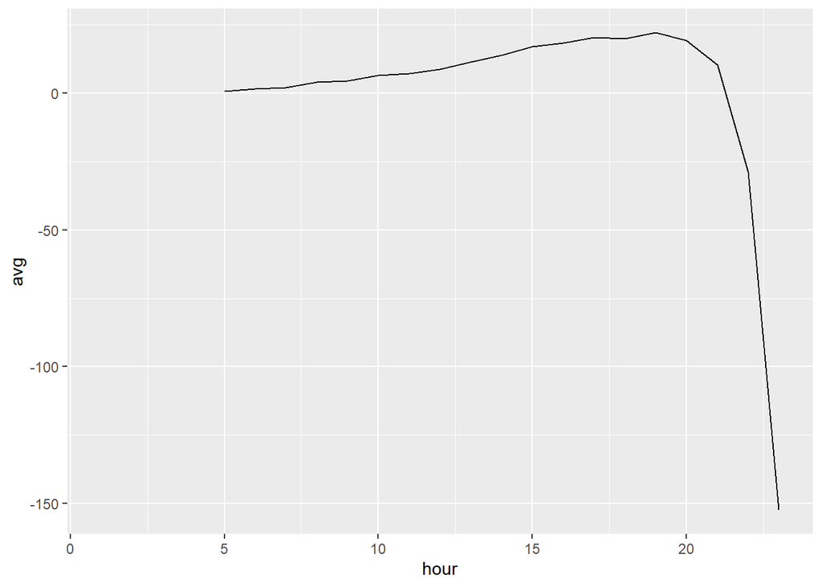

```r
ggplot(new_d_flights, mapping = aes(x = hour, y = avg)) +
  geom_line()
```

```r
new_d_flights
```

```
## # A tibble: 20 × 2
##     hour avg
##    <dbl> <drtn>
##  1     1          NaN mins
##  2     5    0.6877572 mins
##  3     6    1.6427956 mins
##  4     7    1.9140778 mins
##  5     8    4.1279478 mins
##  6     9    4.5116838 mins
##  7    10    6.4982946 mins
##  8    11    7.1916503 mins
##  9    12    8.6148485 mins
## 10    13   11.4376504 mins
## 11    14   13.7636484 mins
## 12    15   16.8945646 mins
## 13    16   18.3492192 mins
## 14    17   20.3310743 mins
## 15    18   19.9358653 mins
## 16    19   22.0958811 mins
## 17    20   19.2028623 mins
## 18    21   10.3162385 mins
## 19    22  -28.8944073 mins
## 20    23 -152.5359661 mins
```

If using just dep_time and sched_dep_time, average delay time decreases after 20h and even its value is negative when the hour is 22 and 23. It’s because the code using dep_time and sched_dep_time cannot consider time across the day.

# Textbook 18.4.4

## Problem 3

Write a function that given your birthday (as a date), returns how old you are in years.

```r
howOld <- function(birthday) {
  age <- as.numeric(today() - birthday)
  return(floor(age / 365.25))
}

my_birthday = ymd("2003-12-16")
howOld(my_birthday)
```

```
## [1] 19
```

# Textbook 26.2.5

## Problem 4

Write your own functions to compute the variance and skewness of a numeric vector. You can look up the definitions on Wikipedia or elsewhere.

```r
cal_variance <- function(x) {
  mean_x <- mean(x)
  dv <- x - mean_x
  var <- sum((x - dv) ** 2) / (length(x)-1)
  return(var)
}

cal_skewness <- function(x) {
  mean_x <- mean(x)
  standard_x <- (x - mean_x) / sqrt(cal_variance(x))
  sk <- sum(standard_x ** 3) / (length(x) - 1)
  return(sk)
}

cal_variance(c(1, 2, 3, 4))
```

```
## [1] 8.333333
```

```r
cal_skewness(c(1, 2, 3, 8))
```

```
## [1] 0.3635792
```

# Textbook 26.5.1

## Problem 1

Read the source code for each of the following two functions, puzzle out what they do, and then brainstorm better names.

```r
library(stringr)
```

```r
f1 <- function(string, prefix) {
  str_sub(string, 1, str_length(prefix)) == prefix
}

f3 <- function(x, y) {
  rep(y, length.out = length(x))
}
```

f1: Determines whether a string has a specific prefix or not  
f3: Repeat y as many times as the length of vector x

```r
is_prefix <- function(string, prefix) {
  str_sub(string, 1, str_length(prefix)) == prefix
}

repeat_vec <- function(x, y) {
  rep(y, length.out = length(x))
}
```